# R Notebook

```r
library(foreign)
library(stringr)
library(dplyr)
library(ggplot2)
```

```r
#hines_2020_raw<-read.spss(hines_location, use.value.label=TRUE,to.data.frame=TRUE)

hines_locations <- Sys.glob(file.path("/Users/benjaminsmith/Google Drive/oregon/data/protected_HINTS_data/","*/hints5*.sav"))

raw_file_list <- vector(mode="list",length<-length(hines_locations))

for (i in 1:length(raw_file_list)){
  hines_filepath <- hines_locations[[i]]
  filename <- basename(hines_filepath)
  spss_rawfile <- read.spss(hines_filepath, use.value.label=TRUE,to.data.frame=TRUE)
  spss_rawfile[["filename"]] <- filename
  raw_file_list[[i]] <- spss_rawfile
}
```

```
/Users/benjaminsmith/Google Drive/oregon/data/protected_HINTS_data//HINTS5- Cycle 2-SPSS-10132020/hints5_cycle2_public.sav: Very long string record(s) found (record type 7, subtype 14), each will be imported in consecutive separate variables/Users/benjaminsmith/Google Drive/oregon/data/protected_HIN…
```

```r
detect_key_cols <- function(spss_item){
    print(spss_item[["filename"]][[1]])
    print("Race_Cat2" %in% colnames(spss_item))
    print(paste0("PR_RUCA_2010", "PR_RUCA_2010" %in% colnames(spss_item)))
    print(paste0("RUC2013", "RUC2013" %in% colnames(spss_item)))

    print("Age" %in% colnames(spss_item))
    print("BMI" %in% colnames(spss_item))
}

lapply(raw_file_list,detect_key_cols)
```

```
[1] "hints5_cycle2_public.sav"
[1] TRUE
[1] "PR_RUCA_2010TRUE"
[1] "RUC2013TRUE"
[1] TRUE
[1] TRUE
[1] "hints5_cycle1_public.sav"
[1] TRUE
[1] "PR_RUCA_2010TRUE"
[1] "RUC2013TRUE"
[1] TRUE
[1] TRUE
[1] "hints5_cycle3_public.sav"
[1] TRUE
[1] "PR_RUCA_2010TRUE"
```

[output cut: 20 more lines]

So let’s just join cycle 5, because all but one of cycle 4 have rural-urban zoning data, and none have RUCA.

To join these we need to do something about all these columns that are different. So let’s find the intersection of columns that are in all items.

```r
shared_colnames <- colnames(raw_file_list[[1]])
for (i in 2:length(raw_file_list)){
  shared_colnames <- intersect(colnames(raw_file_list[[i]]),shared_colnames)
}

#we want a few eextra important columns of interest
cols_to_use <- c(shared_colnames,"Fruit","Vegetables")

#then trim each file back to just these shared columns.
#we've checked it will include the ones we want.
file_list_trimmed <- lapply(
  raw_file_list,
  function(cycle_5_df){
    return(cycle_5_df[intersect(cols_to_use,colnames(cycle_5_df))])
  }

)
```

```r
library(data.table)
hines_cycle5 <- rbindlist(file_list_trimmed,fill=TRUE)
```

Now we need to tidy up the dataset for the key columns we’re interested in.

```r
lapply(
  file_list_trimmed,
  function(cycle_5_df){
    print(table(cycle_5_df[["PR_RUCA_2010"]]))
    #colnames(cycle_5_df)
  }
)
```

```
Metropolitan area core: primary flow within an urbanized are Metropolitan area high commuting: primary flow 30% or more t
                                                        2661                                                          274
Metropolitan area low commuting: primary flow 10% to 30% to  Micropolitan area core: primary flow within an Urban Cluster
                                                          26                                                          218
Micropolitan high commuting: primary flow 30% or more to a l Micropolitan low commuting: primary flow 10% to 30% to a lar
                                                          80                                                           16
Small town core: primary flow within an Urban Cluster of 2,5 Small town high commuting: primary flow 30% or more to a sma
                                                         111                                                           19
Small town low commuting: primary flow 10% to 30% to a small      Rural areas: primary flow to a tract outside a UA or UC
                                                          14                                                           85

Metropolitan area core: primary flow within an urbanized are Metropolitan area high commuting: primary flow 30% or more t
                                                        2553                                                          216
Metropolitan area low commuting: primary flow 10% to 30% to  Micropolitan area core: primary flow within an Urban Cluster
                                                          19                                                          188
Micropolitan high commuting: primary flow 30% or more to a l Micropolitan low commuting: primary flow 10% to 30% to a lar
                                                          67                                                           10
Small town core: primary flow within an Urban Cluster of 2,5 Small town high commuting: primary flow 30% or more to a sma
                                                          99                                                           21
Small town low commuting: primary flow 10% to 30% to a small      Rural areas: primary flow to a tract outside a UA or UC
                                                           4                                                          108

Metropolitan area core: primary flow within an urbanized are Metropolitan area high commuting: primary flow 30% or more t
                                                        4364                                                          372
Metropolitan area low commuting: primary flow 10% to 30% to  Micropolitan area core: primary flow within an Urban Cluster
                                                          40                                                          264
Micropolitan high commuting: primary flow 30% or more to a l Micropolitan low commuting: primary flow 10% to 30% to a lar
                                                         104                                                           14
Small town core: primary flow within an Urban Cluster of 2,5 Small town high commuting: primary flow 30% or more to a sma
                                                         127                                                           40
Small town low commuting: primary flow 10% to 30% to a small      Rural areas: primary flow to a tract outside a UA or UC
                                                          12                                                          100
Not coded: Census tract w/0 population & no rural-urban iden
                                                           1

Metropolitan Micropolitan   Small town        Rural
        3387          274          133           71
[[1]]

Metropolitan area core: primary flow within an urbanized are Metropolitan area high commuting: primary flow 30% or more t
```

[output cut: 27 more lines]

```
Metropolitan area low commuting: primary flow 10% to 30% to  Micropolitan area core: primary flow within an Urban Cluster
                                                          40                                                          264
Micropolitan high commuting: primary flow 30% or more to a l Micropolitan low commuting: primary flow 10% to 30% to a lar
                                                         104                                                           14
Small town core: primary flow within an Urban Cluster of 2,5 Small town high commuting: primary flow 30% or more to a sma
                                                         127                                                           40
Small town low commuting: primary flow 10% to 30% to a small      Rural areas: primary flow to a tract outside a UA or UC
                                                          12                                                          100
Not coded: Census tract w/0 population & no rural-urban iden
                                                           1

[[4]]

Metropolitan Micropolitan   Small town        Rural
        3387          274          133           71
```

```r
table(hines_cycle5$PR_RUCA_2010)
```

```
Metropolitan area core: primary flow within an urbanized are Metropolitan area high commuting: primary flow 30% or more t
                                                        9578                                                          862
Metropolitan area low commuting: primary flow 10% to 30% to  Micropolitan area core: primary flow within an Urban Cluster
                                                          85                                                          670
Micropolitan high commuting: primary flow 30% or more to a l Micropolitan low commuting: primary flow 10% to 30% to a lar
                                                         251                                                           40
Small town core: primary flow within an Urban Cluster of 2,5 Small town high commuting: primary flow 30% or more to a sma
                                                         337                                                           80
Small town low commuting: primary flow 10% to 30% to a small      Rural areas: primary flow to a tract outside a UA or UC
                                                          30                                                          293
Not coded: Census tract w/0 population & no rural-urban iden                                                 Metropolitan
                                                           1                                                         3387
                                                Micropolitan                                                   Small town
                                                         274                                                          133
                                                       Rural
                                                          71
```

OK, so I don’t think we need to tidy this up, we just need to use a bit of regex to process this into our boolean rural item.

```r
#preprocess
hines_cycle5$Age <- as.numeric(as.character(hines_cycle5$Age))
```

```
NAs introduced by coercion
```

```r
hines_cycle5$BMI <- as.numeric(as.character(hines_cycle5$BMI))
```

```
NAs introduced by coercion
```

```r
hines_cycle5$Age_c <- hines_cycle5$Age-38 #using U.S. median age
```

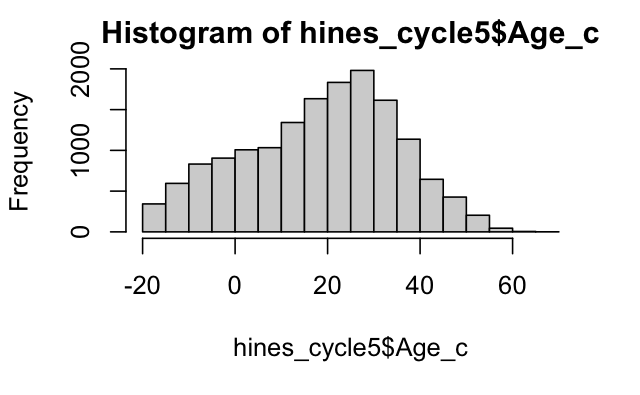

```r
hist(hines_cycle5$Age_c)
```

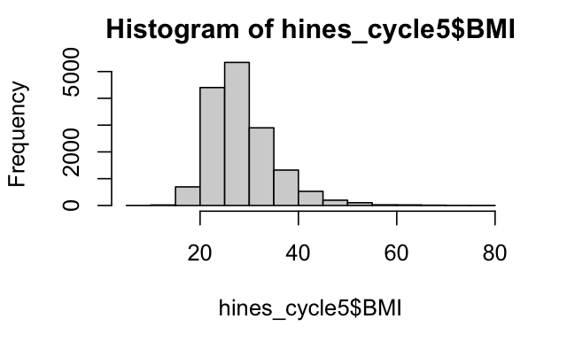

```r
hist(hines_cycle5$BMI)
```

```r
summary(hines_cycle5$SelfGender)
```

```
                                    Missing Data             Multiple responses selected in error
                                             991                                                1
                                            Male                                           Female
                                            6159                                             8573
Missing data (Web partial - Question Never Seen)                   Missing data (Not Ascertained)
                                              43                                              325
```

```r
hines_cycle5$HINESIsRural <- grepl("Metropolitan",hines_cycle5$PR_RUCA_2010)==FALSE
```

Race: join groups across the sets, then re-order in order of frequency

```r
hines_cycle5$RacePreprocessed<- stringr::str_replace(hines_cycle5$Race_Cat2," only","")
#replace small categories
hines_cycle5$RacePreprocessed[hines_cycle5$RacePreprocessed %in% c("Guamanian or Chamorro","Native Hawaiian","Other Pacific Islander")]<-"Pacific Islander"

race_pp_levels <- names(sort(table(hines_cycle5$RacePreprocessed),decreasing = TRUE))

#make "white" category first, because it's the majority category
hines_cycle5$RacePreprocessed <- factor(hines_cycle5$RacePreprocessed,race_pp_levels)
```

```r
table(hines_cycle5$RacePreprocessed)
```

```
                                           White                                            Black
                                           10915                                             2476
                  Missing data (Not Ascertained)                          Multiple races selected
                                            1151                                              582
                                         Chinese                                         Filipino
                                             182                                              149
                                    Asian Indian                                      Other Asian
                                             139                                              133
                American Indian or Alaska Native                                 Pacific Islander
                                             110                                               85
                                      Vietnamese Missing data (Web partial - Question Never Seen)
                                              61                                               43
                                          Korean                                         Japanese
                                              38                                               28
```

```r
hines_cycle5$HHInc[hines_cycle5$HHInc=="Missing Data (Not Ascertained)"]<-NA
hines_cycle5$HHInc[hines_cycle5$HHInc=="Missing data (Web partial - Question Never Seen)"]<-NA
median_hh_inc<-median(as.integer(hines_cycle5$HHInc),na.rm=TRUE)
hines_cycle5$HHInc_r <- as.integer(hines_cycle5$HHInc)-median_hh_inc
```

```r
hines_cycle5$WeeklyMinutesModerateExercise_i <- as.integer(as.character(hines_cycle5$WeeklyMinutesModerateExercise))
```

```
NAs introduced by coercion
```

```r
table(hines_cycle5$Fruit)
```

```
                  Missing data (Not Ascertained)             Multiple responses selected in error
                                             139                                               40
                                            None                                    ½ cup or less
                                             887                                              592
                                  ½ cup to 1 cup                                      1 to 2 cups
                                             817                                             2518
                                     2 to 3 cups                                      3 to 4 cups
                                             904                                              292
                                  4 or more cups Missing data (Web partial - Question Never Seen)
                                             172                                               15
                                 1/2 cup or less                                 1/2 cup to 1 cup
                                             974                                             1373
```

```r
hines_cycle5$Fruit[
  hines_cycle5$Fruit %in% c("Missing data (Not Ascertained)","Multiple responses selected in error","Missing data (Web partial - Question Never Seen)")] <- NA

#some recoding now
hines_cycle5$Fruit[hines_cycle5$Fruit=="½ cup or less"]<-"1/2 cup or less"
hines_cycle5$Fruit[hines_cycle5$Fruit==" ½ cup to 1 cup"]<-"1/2 cup to 1 cup"
table(hines_cycle5$Fruit)
```

```
                  Missing data (Not Ascertained)             Multiple responses selected in error
                                               0                                                0
                                            None                                    ½ cup or less
                                             887                                                0
                                  ½ cup to 1 cup                                      1 to 2 cups
                                             817                                             2518
                                     2 to 3 cups                                      3 to 4 cups
                                             904                                              292
                                  4 or more cups Missing data (Web partial - Question Never Seen)
                                             172                                                0
                                 1/2 cup or less                                 1/2 cup to 1 cup
                                            1566                                             1373
```

```r
#now code factors into integers.
hines_cycle5$Fruit_i <- as.integer(NA)
hines_cycle5$Fruit_i[hines_cycle5$Fruit=="None"]<-0
hines_cycle5$Fruit_i[hines_cycle5$Fruit=="1/2 cup or less"]<-1
hines_cycle5$Fruit_i[hines_cycle5$Fruit=="1/2 cup to 1 cup"]<-2
hines_cycle5$Fruit_i[hines_cycle5$Fruit=="1 to 2 cups"]<-3
hines_cycle5$Fruit_i[hines_cycle5$Fruit=="2 to 3 cups"]<-4
hines_cycle5$Fruit_i[hines_cycle5$Fruit=="3 to 4 cups"]<-5
hines_cycle5$Fruit_i[hines_cycle5$Fruit=="4 or more cups"]<-6
table(hines_cycle5$Fruit_i,hines_cycle5$Fruit)
```

```
    Missing data (Not Ascertained) Multiple responses selected in error None ½ cup or less ½ cup to 1 cup 1 to 2 cups
  0                              0                                    0  887             0              0           0
  1                              0                                    0    0             0              0           0
  2                              0                                    0    0             0              0           0
  3                              0                                    0    0             0              0        2518
  4                              0                                    0    0             0              0           0
  5                              0                                    0    0             0              0           0
  6                              0                                    0    0             0              0           0

    2 to 3 cups 3 to 4 cups 4 or more cups Missing data (Web partial - Question Never Seen) 1/2 cup or less
  0           0           0              0                                                0               0
  1           0           0              0                                                0            1566
  2           0           0              0                                                0               0
  3           0           0              0                                                0               0
  4         904           0              0                                                0               0
  5           0         292              0                                                0               0
  6           0           0            172                                                0               0

    1/2 cup to 1 cup
  0                0
  1                0
  2             1373
  3                0
  4                0
  5                0
  6                0
```

```r
hines_cycle5$Fruit_z <- (hines_cycle5$Fruit_i - mean(hines_cycle5$Fruit_i,na.rm=TRUE))/sd(hines_cycle5$Fruit_i,na.rm=TRUE)

hines_cycle5$Vegetables[
  hines_cycle5$Vegetables %in% c("Missing data (Not Ascertained)","Multiple responses selected in error","Missing data (Web partial - Question Never Seen)")] <- NA

hines_cycle5$Vegetables[hines_cycle5$Vegetables=="½ cup or less"]<-"1/2 cup or less"
hines_cycle5$Vegetables[hines_cycle5$Vegetables==" ½ cup to 1 cup"]<-"1/2 cup to 1 cup"
table(hines_cycle5$Vegetables)
```

```
                  Missing data (Not Ascertained)             Multiple responses selected in error
                                               0                                                0
                                            None                                    ½ cup or less
                                             501                                                0
                                  ½ cup to 1 cup                                      1 to 2 cups
                                             771                                             2751
                                     2 to 3 cups                                      3 to 4 cups
                                            1302                                              514
                                  4 or more cups Missing data (Web partial - Question Never Seen)
                                             275                                                0
                                 1/2 cup or less                                 1/2 cup to 1 cup
                                            1206                                             1211
```

```r
#now code factors into integers.
hines_cycle5$Vegetables_i <- as.integer(NA)
hines_cycle5$Vegetables_i[hines_cycle5$Vegetables=="None"]<-0
hines_cycle5$Vegetables_i[hines_cycle5$Vegetables=="1/2 cup or less"]<-1
hines_cycle5$Vegetables_i[hines_cycle5$Vegetables=="1/2 cup to 1 cup"]<-2
hines_cycle5$Vegetables_i[hines_cycle5$Vegetables=="1 to 2 cups"]<-3
hines_cycle5$Vegetables_i[hines_cycle5$Vegetables=="2 to 3 cups"]<-4
hines_cycle5$Vegetables_i[hines_cycle5$Vegetables=="3 to 4 cups"]<-5
hines_cycle5$Vegetables_i[hines_cycle5$Vegetables=="4 or more cups"]<-6
table(hines_cycle5$Vegetables_i,hines_cycle5$Vegetables)
```

```
    Missing data (Not Ascertained) Multiple responses selected in error None ½ cup or less ½ cup to 1 cup 1 to 2 cups
  0                              0                                    0  501             0              0           0
  1                              0                                    0    0             0              0           0
  2                              0                                    0    0             0              0           0
  3                              0                                    0    0             0              0        2751
  4                              0                                    0    0             0              0           0
  5                              0                                    0    0             0              0           0
  6                              0                                    0    0             0              0           0

    2 to 3 cups 3 to 4 cups 4 or more cups Missing data (Web partial - Question Never Seen) 1/2 cup or less
  0           0           0              0                                                0               0
  1           0           0              0                                                0            1206
  2           0           0              0                                                0               0
  3           0           0              0                                                0               0
  4        1302           0              0                                                0               0
  5           0         514              0                                                0               0
  6           0           0            275                                                0               0

    1/2 cup to 1 cup
  0                0
  1                0
  2             1211
  3                0
  4                0
  5                0
  6                0
```

```r
hines_cycle5$Vegetables_z <- (hines_cycle5$Vegetables_i - mean(hines_cycle5$Vegetables_i,na.rm=TRUE))/sd(hines_cycle5$Vegetables_i,na.rm=TRUE)
```

## Women

```r
data_to_measure <- hines_cycle5 %>%
  filter(SelfGender=="Female")

summary(lm(BMI~Age_c+I(Age_c^2)+HINESIsRural+RacePreprocessed+filename,data_to_measure))
```

```
Call:
lm(formula = BMI ~ Age_c + I(Age_c^2) + HINESIsRural + RacePreprocessed +
    filename, data = data_to_measure)

Residuals:
    Min      1Q  Median      3Q     Max
-17.504  -4.793  -1.275   3.543  49.646

Coefficients:
                                                   Estimate Std. Error t value Pr(>|t|)
(Intercept)                                      27.5851619  0.1950105 141.455  < 2e-16 ***
Age_c                                             0.0985217  0.0089358  11.026  < 2e-16 ***
I(Age_c^2)                                       -0.0029420  0.0002313 -12.718  < 2e-16 ***
HINESIsRuralTRUE                                  1.1242609  0.2198749   5.113 3.24e-07 ***
RacePreprocessedBlack                             3.4898139  0.2022802  17.252  < 2e-16 ***
RacePreprocessedMissing data (Not Ascertained)    1.3943125  0.4045324   3.447 0.000570 ***
RacePreprocessedMultiple races selected           1.4896328  0.4030888   3.696 0.000221 ***
RacePreprocessedChinese                          -5.6866636  0.7657254  -7.427 1.23e-13 ***
RacePreprocessedFilipino                         -2.3956039  0.7421342  -3.228 0.001252 **
RacePreprocessedAsian Indian                     -2.2132178  0.9501447  -2.329 0.019865 *
RacePreprocessedOther Asian                      -3.4705438  0.9327002  -3.721 0.000200 ***
RacePreprocessedAmerican Indian or Alaska Native  1.8811077  0.8442003   2.228 0.025889 *
RacePreprocessedPacific Islander                  3.0596039  0.9863900   3.102 0.001930 **
RacePreprocessedVietnamese                       -6.1030558  1.3787516  -4.427 9.70e-06 ***
RacePreprocessedKorean                           -4.7642570  1.6228837  -2.936 0.003337 **
RacePreprocessedJapanese                         -4.5374123  1.9854259  -2.285 0.022317 *
filenamehints5_cycle2_public.sav                  0.2488242  0.2306748   1.079 0.280762
filenamehints5_cycle3_public.sav                  0.3274156  0.2115388   1.548 0.121714
filenamehints5_cycle4_public.sav                  0.3316709  0.2274404   1.458 0.144803
---
Signif. codes:  0 ‘***’ 0.001 ‘**’ 0.01 ‘*’ 0.05 ‘.’ 0.1 ‘ ’ 1

Residual standard error: 6.868 on 8217 degrees of freedom
  (337 observations deleted due to missingness)
Multiple R-squared:  0.07857,   Adjusted R-squared:  0.07655
F-statistic: 38.93 on 18 and 8217 DF,  p-value: < 2.2e-16
```

## Men

```r
data_to_measure <- hines_cycle5 %>%
  filter(SelfGender=="Male")

table(data_to_measure$HINESIsRural)
```

```
FALSE  TRUE
 5359   800
```

```r
summary(lm(BMI~Age_c+I(Age_c^2)+HINESIsRural+RacePreprocessed+filename,data_to_measure))
```

```
Call:
lm(formula = BMI ~ Age_c + I(Age_c^2) + HINESIsRural + RacePreprocessed +
    filename, data = data_to_measure)

Residuals:
    Min      1Q  Median      3Q     Max
-18.833  -3.693  -0.824   2.667  44.538

Coefficients:
                                                   Estimate Std. Error t value Pr(>|t|)
(Intercept)                                      28.5485051  0.1918578 148.800  < 2e-16 ***
Age_c                                             0.1057382  0.0092387  11.445  < 2e-16 ***
I(Age_c^2)                                       -0.0030727  0.0002422 -12.684  < 2e-16 ***
HINESIsRuralTRUE                                  0.3158125  0.2186946   1.444  0.14877
RacePreprocessedBlack                             0.4068998  0.2282884   1.782  0.07474 .
RacePreprocessedMissing data (Not Ascertained)    0.8016548  0.3590422   2.233  0.02560 *
RacePreprocessedMultiple races selected           0.2367684  0.3914952   0.605  0.54535
RacePreprocessedChinese                          -3.3498790  0.6454049  -5.190 2.17e-07 ***
RacePreprocessedFilipino                         -2.1782977  0.7724731  -2.820  0.00482 **
RacePreprocessedAsian Indian                     -3.0058992  0.6711079  -4.479 7.64e-06 ***
RacePreprocessedOther Asian                      -3.1551519  0.6769338  -4.661 3.22e-06 ***
RacePreprocessedAmerican Indian or Alaska Native  1.0215725  0.9576033   1.067  0.28610
RacePreprocessedPacific Islander                  0.1213985  1.1317036   0.107  0.91458
RacePreprocessedVietnamese                       -5.7717948  1.0336821  -5.584 2.46e-08 ***
RacePreprocessedKorean                           -3.5837917  1.4133864  -2.536  0.01125 *
RacePreprocessedJapanese                         -4.2866604  1.4596083  -2.937  0.00333 **
filenamehints5_cycle2_public.sav                 -0.2101147  0.2260806  -0.929  0.35273
filenamehints5_cycle3_public.sav                 -0.2071244  0.2045688  -1.012  0.31134
filenamehints5_cycle4_public.sav                 -0.1641820  0.2202061  -0.746  0.45595
---
Signif. codes:  0 ‘***’ 0.001 ‘**’ 0.01 ‘*’ 0.05 ‘.’ 0.1 ‘ ’ 1

Residual standard error: 5.636 on 5974 degrees of freedom
  (166 observations deleted due to missingness)
Multiple R-squared:  0.04948,   Adjusted R-squared:  0.04662
F-statistic: 17.28 on 18 and 5974 DF,  p-value: < 2.2e-16
```

```r
summary(lm(BMI~Age_c+I(Age_c^2)+HINESIsRural+filename,data_to_measure))
```

```
Call:
lm(formula = BMI ~ Age_c + I(Age_c^2) + HINESIsRural + filename,
    data = data_to_measure)

Residuals:
    Min      1Q  Median      3Q     Max
-18.693  -3.803  -0.860   2.733  44.612

Coefficients:
                                   Estimate Std. Error t value Pr(>|t|)
(Intercept)                      28.4014992  0.1858298 152.836   <2e-16 ***
Age_c                             0.1094789  0.0092907  11.784   <2e-16 ***
I(Age_c^2)                       -0.0031471  0.0002442 -12.885   <2e-16 ***
HINESIsRuralTRUE                  0.4490637  0.2194884   2.046   0.0408 *
filenamehints5_cycle2_public.sav -0.1856897  0.2281917  -0.814   0.4158
filenamehints5_cycle3_public.sav -0.1962743  0.2063639  -0.951   0.3416
filenamehints5_cycle4_public.sav -0.1290454  0.2218536  -0.582   0.5608
---
Signif. codes:  0 ‘***’ 0.001 ‘**’ 0.01 ‘*’ 0.05 ‘.’ 0.1 ‘ ’ 1

Residual standard error: 5.693 on 5986 degrees of freedom
  (166 observations deleted due to missingness)
Multiple R-squared:  0.02824,   Adjusted R-squared:  0.02727
F-statistic: 28.99 on 6 and 5986 DF,  p-value: < 2.2e-16
```

Result here is the OPPOSITE of my Oregon dataset. There, men, but not women, show a robust relationship between Rurality and BMI. Here, the relationship is weak for men, but very strong for women.

```r
hines_cycle5 %>% group_by(SelfGender) %>% summarize(mean_height_feet = mean(as.numeric(as.character(Height_Feet)),na.rm=TRUE))
```

```
NAs introduced by coercionNAs introduced by coercionNAs introduced by coercionNAs introduced by coercionNAs introduced by coercion
```

| SelfGender | mean_height_feet |
| --- | --- |
| Missing Data | 5.089655 |
| Multiple responses selected in error | 5.000000 |
| Male | 5.296284 |
| Female | 4.971527 |
| Missing data (Web partial - Question Never Seen) | 5.166667 |
| Missing data (Not Ascertained) | 5.103806 |

```r
hines_cycle5 %>% group_by(SelfGender,HINESIsRural) %>% summarize(count = n())
```

| SelfGender | HINESIsRural | count |
| --- | --- | --- |
| Missing Data | FALSE | 846 |
| Missing Data | TRUE | 145 |
| Multiple responses selected in error | FALSE | 1 |
| Male | FALSE | 5359 |
| Male | TRUE | 800 |
| Female | FALSE | 7375 |
| Female | TRUE | 1198 |
| Missing data (Web partial - Question Never Seen) | FALSE | 41 |
| Missing data (Web partial - Question Never Seen) | TRUE | 2 |
| Missing data (Not Ascertained) | FALSE | 290 |

[output cut: 1 more lines]

## Interaction term

```r
data_to_measure <- hines_cycle5 %>%
  filter(SelfGender %in% c("Male","Female"))
```

```r
data_to_measure <- hines_cycle5 %>%
  filter(SelfGender %in% c("Male","Female"))

summary(lm(BMI~Age_c+I(Age_c^2)+HINESIsRural+SelfGender+RacePreprocessed+filename,data_to_measure))
```

```
Call:
lm(formula = BMI ~ Age_c + I(Age_c^2) + HINESIsRural + SelfGender +
    RacePreprocessed + filename, data = data_to_measure)

Residuals:
    Min      1Q  Median      3Q     Max
-18.610  -4.361  -1.075   3.112  49.383

Coefficients:
                                                   Estimate Std. Error t value Pr(>|t|)
(Intercept)                                      28.0143100  0.1538608 182.076  < 2e-16 ***
Age_c                                             0.1024941  0.0065184  15.724  < 2e-16 ***
I(Age_c^2)                                       -0.0030239  0.0001696 -17.830  < 2e-16 ***
HINESIsRuralTRUE                                  0.7891295  0.1579832   4.995 5.95e-07 ***
SelfGenderFemale                                 -0.0171552  0.1094029  -0.157 0.875399
RacePreprocessedBlack                             2.4194092  0.1523358  15.882  < 2e-16 ***
RacePreprocessedMissing data (Not Ascertained)    1.1375916  0.2767291   4.111 3.96e-05 ***
RacePreprocessedMultiple races selected           0.9491439  0.2868848   3.308 0.000940 ***
RacePreprocessedChinese                          -4.5071714  0.5112292  -8.816  < 2e-16 ***
RacePreprocessedFilipino                         -2.3193496  0.5430206  -4.271 1.96e-05 ***
RacePreprocessedAsian Indian                     -2.5779961  0.5774343  -4.465 8.08e-06 ***
RacePreprocessedOther Asian                      -3.2175963  0.5756055  -5.590 2.31e-08 ***
RacePreprocessedAmerican Indian or Alaska Native  1.5571764  0.6372541   2.444 0.014555 *
RacePreprocessedPacific Islander                  2.0293707  0.7475023   2.715 0.006638 **
RacePreprocessedVietnamese                       -5.8775496  0.8664009  -6.784 1.22e-11 ***
RacePreprocessedKorean                           -4.2234800  1.1003417  -3.838 0.000124 ***
RacePreprocessedJapanese                         -4.3237176  1.2340429  -3.504 0.000460 ***
filenamehints5_cycle2_public.sav                  0.0550264  0.1647480   0.334 0.738382
filenamehints5_cycle3_public.sav                  0.1009514  0.1502195   0.672 0.501578
filenamehints5_cycle4_public.sav                  0.1067370  0.1616249   0.660 0.509008
---
Signif. codes:  0 ‘***’ 0.001 ‘**’ 0.01 ‘*’ 0.05 ‘.’ 0.1 ‘ ’ 1

Residual standard error: 6.4 on 14209 degrees of freedom
  (503 observations deleted due to missingness)
Multiple R-squared:  0.06176,   Adjusted R-squared:  0.06051
F-statistic: 49.23 on 19 and 14209 DF,  p-value: < 2.2e-16
```

```r
summary(lm(BMI~Age_c+I(Age_c^2)+HINESIsRural*SelfGender+RacePreprocessed+filename,data_to_measure))
```

```
Call:
lm(formula = BMI ~ Age_c + I(Age_c^2) + HINESIsRural * SelfGender +
    RacePreprocessed + filename, data = data_to_measure)

Residuals:
    Min      1Q  Median      3Q     Max
-18.655  -4.342  -1.075   3.112  49.418

Coefficients:
                                                   Estimate Std. Error t value Pr(>|t|)
(Intercept)                                      28.0588905  0.1556403 180.280  < 2e-16 ***
Age_c                                             0.1024395  0.0065179  15.717  < 2e-16 ***
I(Age_c^2)                                       -0.0030198  0.0001696 -17.806  < 2e-16 ***
HINESIsRuralTRUE                                  0.4302202  0.2468386   1.743 0.081369 .
SelfGenderFemale                                 -0.0984309  0.1175229  -0.838 0.402300
RacePreprocessedBlack                             2.4219273  0.1523278  15.899  < 2e-16 ***
RacePreprocessedMissing data (Not Ascertained)    1.1335286  0.2767123   4.096 4.22e-05 ***
RacePreprocessedMultiple races selected           0.9540219  0.2868704   3.326 0.000884 ***
RacePreprocessedChinese                          -4.5138556  0.5111949  -8.830  < 2e-16 ***
RacePreprocessedFilipino                         -2.3299050  0.5429999  -4.291 1.79e-05 ***
RacePreprocessedAsian Indian                     -2.5918783  0.5774284  -4.489 7.22e-06 ***
RacePreprocessedOther Asian                      -3.2278709  0.5755788  -5.608 2.08e-08 ***
RacePreprocessedAmerican Indian or Alaska Native  1.5455216  0.6372260   2.425 0.015304 *
RacePreprocessedPacific Islander                  2.0367218  0.7474445   2.725 0.006440 **
RacePreprocessedVietnamese                       -5.8673862  0.8663389  -6.773 1.31e-11 ***
RacePreprocessedKorean                           -4.2347771  1.1002580  -3.849 0.000119 ***
RacePreprocessedJapanese                         -4.3303328  1.2339358  -3.509 0.000451 ***
filenamehints5_cycle2_public.sav                  0.0560372  0.1647339   0.340 0.733735
filenamehints5_cycle3_public.sav                  0.1020233  0.1502069   0.679 0.497011
filenamehints5_cycle4_public.sav                  0.1076032  0.1616109   0.666 0.505539
HINESIsRuralTRUE:SelfGenderFemale                 0.6035344  0.3189470   1.892 0.058475 .
---
Signif. codes:  0 ‘***’ 0.001 ‘**’ 0.01 ‘*’ 0.05 ‘.’ 0.1 ‘ ’ 1

Residual standard error: 6.4 on 14208 degrees of freedom
  (503 observations deleted due to missingness)
Multiple R-squared:  0.062, Adjusted R-squared:  0.06068
F-statistic: 46.95 on 20 and 14208 DF,  p-value: < 2.2e-16
```

What if we restrict to just Pacific North West? do we have neought data for that?

## subset close as I can get to Oregon

We dont’ have pacific north west. we might have a proxy if we go to the “Pacific” census division, but then exclude high-minority areas. Might leave us with few data points but let’s see…

```r
pacific_low_minority <- hines_cycle5 %>% filter(Stratum=="Low Minority Areas" & CENSDIV == "Pacific")
```

```r
data_to_measure <- pacific_low_minority %>%
  filter(SelfGender=="Male")

table(data_to_measure$HINESIsRural)
```

```
FALSE  TRUE
  303    47
```

```r
summary(lm(BMI~Age+I(Age^2)+HINESIsRural+RacePreprocessed+filename,data_to_measure))
```

```
Call:
lm(formula = BMI ~ Age + I(Age^2) + HINESIsRural + RacePreprocessed +
    filename, data = data_to_measure)

Residuals:
    Min      1Q  Median      3Q     Max
-11.273  -3.499  -0.880   2.254  32.400

Coefficients:
                                                  Estimate Std. Error t value Pr(>|t|)
(Intercept)                                      21.621955   3.234946   6.684 1.03e-10 ***
Age                                               0.236837   0.115770   2.046   0.0416 *
I(Age^2)                                         -0.001974   0.001008  -1.958   0.0511 .
HINESIsRuralTRUE                                  0.726130   0.913493   0.795   0.4273
RacePreprocessedBlack                             3.181594   3.266455   0.974   0.3308
RacePreprocessedMissing data (Not Ascertained)    2.669982   1.506469   1.772   0.0773 .
RacePreprocessedMultiple races selected          -1.409626   1.378641  -1.022   0.3073
RacePreprocessedChinese                          -3.161184   1.507669  -2.097   0.0368 *
RacePreprocessedFilipino                         -0.852313   2.035159  -0.419   0.6756
RacePreprocessedAsian Indian                     -3.263880   2.838671  -1.150   0.2511
RacePreprocessedOther Asian                      -2.716341   2.218385  -1.224   0.2217
RacePreprocessedAmerican Indian or Alaska Native 10.690374   5.670865   1.885   0.0603 .
RacePreprocessedPacific Islander                 -1.843149   5.648684  -0.326   0.7444
RacePreprocessedVietnamese                       -4.291633   2.555852  -1.679   0.0941 .
RacePreprocessedKorean                           -2.867160   2.557644  -1.121   0.2631
RacePreprocessedJapanese                         -3.771530   2.556771  -1.475   0.1412
filenamehints5_cycle2_public.sav                 -0.974832   0.936825  -1.041   0.2989
filenamehints5_cycle3_public.sav                  0.073422   0.851749   0.086   0.9314
filenamehints5_cycle4_public.sav                 -1.181051   0.937111  -1.260   0.2085
---
Signif. codes:  0 ‘***’ 0.001 ‘**’ 0.01 ‘*’ 0.05 ‘.’ 0.1 ‘ ’ 1

Residual standard error: 5.601 on 322 degrees of freedom
  (9 observations deleted due to missingness)
Multiple R-squared:  0.09239,   Adjusted R-squared:  0.04165
F-statistic: 1.821 on 18 and 322 DF,  p-value: 0.02211
```

```r
summary(lm(BMI~Age+I(Age^2)+HINESIsRural+filename,data_to_measure))
```

```
Call:
lm(formula = BMI ~ Age + I(Age^2) + HINESIsRural + filename,
    data = data_to_measure)

Residuals:
    Min      1Q  Median      3Q     Max
-11.232  -3.578  -1.212   2.330  32.956

Coefficients:
                                   Estimate Std. Error t value Pr(>|t|)
(Intercept)                      21.3575044  3.1869413   6.702 8.78e-11 ***
Age                               0.2458659  0.1146946   2.144   0.0328 *
I(Age^2)                         -0.0020602  0.0009988  -2.063   0.0399 *
HINESIsRuralTRUE                  1.1071299  0.9132983   1.212   0.2263
filenamehints5_cycle2_public.sav -1.3640400  0.9241743  -1.476   0.1409
filenamehints5_cycle3_public.sav -0.4387318  0.8494062  -0.517   0.6058
filenamehints5_cycle4_public.sav -1.4639984  0.9169950  -1.597   0.1113
---
Signif. codes:  0 ‘***’ 0.001 ‘**’ 0.01 ‘*’ 0.05 ‘.’ 0.1 ‘ ’ 1

Residual standard error: 5.685 on 334 degrees of freedom
  (9 observations deleted due to missingness)
Multiple R-squared:  0.0303,    Adjusted R-squared:  0.01289
F-statistic:  1.74 on 6 and 334 DF,  p-value: 0.1111
```

```r
data_to_measure <- pacific_low_minority %>%
  filter(SelfGender=="Female")

table(data_to_measure$HINESIsRural)
```

```
FALSE  TRUE
  399    55
```

```r
summary(lm(BMI~Age+I(Age^2)+HINESIsRural+RacePreprocessed+filename,data_to_measure))
```

```
Call:
lm(formula = BMI ~ Age + I(Age^2) + HINESIsRural + RacePreprocessed +
    filename, data = data_to_measure)

Residuals:
    Min      1Q  Median      3Q     Max
-17.241  -3.936  -1.025   2.754  28.786

Coefficients:
                                                   Estimate Std. Error t value Pr(>|t|)
(Intercept)                                      16.8148363  2.5336425   6.637  9.9e-11 ***
Age                                               0.2837164  0.0931895   3.045  0.00248 **
I(Age^2)                                         -0.0021097  0.0008379  -2.518  0.01218 *
HINESIsRuralTRUE                                  2.2486590  0.8818612   2.550  0.01113 *
RacePreprocessedBlack                            -0.2015671  2.0844752  -0.097  0.92301
RacePreprocessedMissing data (Not Ascertained)    4.8284357  2.2449871   2.151  0.03206 *
RacePreprocessedMultiple races selected           0.7847278  1.1471786   0.684  0.49432
RacePreprocessedChinese                          -4.9792633  1.5454286  -3.222  0.00137 **
RacePreprocessedFilipino                         -2.8673218  2.2741572  -1.261  0.20807
RacePreprocessedAsian Indian                     -3.1223137  2.9791836  -1.048  0.29522
RacePreprocessedOther Asian                      -4.6472239  3.4381576  -1.352  0.17721
RacePreprocessedAmerican Indian or Alaska Native  7.4990936  2.6662528   2.813  0.00514 **
RacePreprocessedPacific Islander                  4.2552795  5.8638761   0.726  0.46844
RacePreprocessedVietnamese                       -2.2753950  2.6434795  -0.861  0.38986
RacePreprocessedKorean                           -4.1820311  2.4102923  -1.735  0.08346 .
RacePreprocessedJapanese                         -1.9664013  2.6337370  -0.747  0.45571
filenamehints5_cycle2_public.sav                  1.4132221  0.8436913   1.675  0.09467 .
filenamehints5_cycle3_public.sav                  0.7588966  0.7396051   1.026  0.30544
filenamehints5_cycle4_public.sav                  0.9609902  0.8194431   1.173  0.24156
---
Signif. codes:  0 ‘***’ 0.001 ‘**’ 0.01 ‘*’ 0.05 ‘.’ 0.1 ‘ ’ 1

Residual standard error: 5.825 on 421 degrees of freedom
  (14 observations deleted due to missingness)
Multiple R-squared:  0.1411,    Adjusted R-squared:  0.1043
F-statistic: 3.841 on 18 and 421 DF,  p-value: 2.869e-07
```

```r
summary(lm(BMI~Age+I(Age^2)+HINESIsRural+filename,data_to_measure))
```

```
Call:
lm(formula = BMI ~ Age + I(Age^2) + HINESIsRural + filename,
    data = data_to_measure)

Residuals:
    Min      1Q  Median      3Q     Max
-11.733  -4.157  -1.055   2.673  28.975

Coefficients:
                                   Estimate Std. Error t value Pr(>|t|)
(Intercept)                      15.7302877  2.5062629   6.276 8.42e-10 ***
Age                               0.3184457  0.0937757   3.396 0.000747 ***
I(Age^2)                         -0.0023904  0.0008466  -2.824 0.004969 **
HINESIsRuralTRUE                  2.4669937  0.8756934   2.817 0.005066 **
filenamehints5_cycle2_public.sav  1.5100354  0.8583657   1.759 0.079250 .
filenamehints5_cycle3_public.sav  0.5164047  0.7517395   0.687 0.492484
filenamehints5_cycle4_public.sav  0.8470120  0.8250981   1.027 0.305201
---
Signif. codes:  0 ‘***’ 0.001 ‘**’ 0.01 ‘*’ 0.05 ‘.’ 0.1 ‘ ’ 1

Residual standard error: 5.967 on 433 degrees of freedom
  (14 observations deleted due to missingness)
Multiple R-squared:  0.0727,    Adjusted R-squared:  0.05985
F-statistic: 5.658 on 6 and 433 DF,  p-value: 1.13e-05
```

So for Pacific, low minority areas, we still see that Rurality is irrelevant to BMI, for men, but relevant for women. That’s the opposite to what we observed in our survey of Oregon specifically, where rurality was relevant to BMI for men, but irrelevant for women.

We could just look at Whites specifically, which would cut out questions about race interactions…

```r
data_to_measure <- pacific_low_minority %>%
  filter(SelfGender=="Male") %>% filter(RacePreprocessed=="White")

table(data_to_measure$HINESIsRural)
```

```
FALSE  TRUE
  216    43
```

```r
summary(lm(BMI~Age+I(Age^2)+HINESIsRural+filename,data_to_measure))
```

```
Call:
lm(formula = BMI ~ Age + I(Age^2) + HINESIsRural + filename,
    data = data_to_measure)

Residuals:
    Min      1Q  Median      3Q     Max
-11.715  -3.541  -1.030   2.409  32.687

Coefficients:
                                  Estimate Std. Error t value Pr(>|t|)
(Intercept)                      21.744347   4.082055   5.327 2.25e-07 ***
Age                               0.216374   0.146377   1.478    0.141
I(Age^2)                         -0.001632   0.001265  -1.290    0.198
HINESIsRuralTRUE                  0.931918   0.975099   0.956    0.340
filenamehints5_cycle2_public.sav -0.887533   1.059537  -0.838    0.403
filenamehints5_cycle3_public.sav -0.503006   1.020435  -0.493    0.622
filenamehints5_cycle4_public.sav -1.403131   1.071812  -1.309    0.192
---
Signif. codes:  0 ‘***’ 0.001 ‘**’ 0.01 ‘*’ 0.05 ‘.’ 0.1 ‘ ’ 1

Residual standard error: 5.716 on 247 degrees of freedom
  (5 observations deleted due to missingness)
Multiple R-squared:  0.02486,   Adjusted R-squared:  0.001171
F-statistic: 1.049 on 6 and 247 DF,  p-value: 0.3939
```

```r
data_to_measure <- pacific_low_minority %>%
  filter(SelfGender=="Female") %>% filter(RacePreprocessed=="White")

table(data_to_measure$HINESIsRural)
```

```
FALSE  TRUE
  315    41
```

```r
summary(lm(BMI~Age+I(Age^2)+HINESIsRural+filename,data_to_measure))
```

```
Call:
lm(formula = BMI ~ Age + I(Age^2) + HINESIsRural + filename,
    data = data_to_measure)

Residuals:
    Min      1Q  Median      3Q     Max
-11.579  -4.142  -1.148   2.963  28.609

Coefficients:
                                  Estimate Std. Error t value Pr(>|t|)
(Intercept)                      16.972636   3.026199   5.609 4.25e-08 ***
Age                               0.270226   0.111161   2.431  0.01558 *
I(Age^2)                         -0.002013   0.000990  -2.034  0.04276 *
HINESIsRuralTRUE                  2.794875   0.994634   2.810  0.00524 **
filenamehints5_cycle2_public.sav  1.714738   0.944447   1.816  0.07032 .
filenamehints5_cycle3_public.sav  0.883652   0.844668   1.046  0.29624
filenamehints5_cycle4_public.sav  1.447813   0.923301   1.568  0.11780
---
Signif. codes:  0 ‘***’ 0.001 ‘**’ 0.01 ‘*’ 0.05 ‘.’ 0.1 ‘ ’ 1

Residual standard error: 5.879 on 338 degrees of freedom
  (11 observations deleted due to missingness)
Multiple R-squared:  0.06428,   Adjusted R-squared:  0.04767
F-statistic:  3.87 on 6 and 338 DF,  p-value: 0.0009474
```

What about whites in low minority areas across the whole dataset?

```r
data_to_measure <- hines_cycle5 %>% filter(Stratum=="Low Minority Areas" & RacePreprocessed == "White") %>% filter(SelfGender=="Female")
table(data_to_measure$HINESIsRural)
```

```
FALSE  TRUE
 2387   615
```

```r
summary(lm(BMI~Age+I(Age^2)+HINESIsRural+filename+CENSDIV,data_to_measure))
```

```
Call:
lm(formula = BMI ~ Age + I(Age^2) + HINESIsRural + filename +
    CENSDIV, data = data_to_measure)

Residuals:
    Min      1Q  Median      3Q     Max
-16.885  -4.606  -1.359   3.215  45.401

Coefficients:
                                   Estimate Std. Error t value Pr(>|t|)
(Intercept)                      20.5917791  1.2206018  16.870  < 2e-16 ***
Age                               0.2171872  0.0414162   5.244 1.68e-07 ***
I(Age^2)                         -0.0019746  0.0003684  -5.360 8.95e-08 ***
HINESIsRuralTRUE                  1.7972648  0.3069760   5.855 5.31e-09 ***
filenamehints5_cycle2_public.sav  0.1340456  0.3569504   0.376 0.707294
filenamehints5_cycle3_public.sav  0.2994484  0.3274024   0.915 0.360468
filenamehints5_cycle4_public.sav  0.0299350  0.3551188   0.084 0.932827
CENSDIVMiddle Atlantic            1.0208081  0.5752551   1.775 0.076080 .
CENSDIVEast North Central         1.8906028  0.5465238   3.459 0.000549 ***
CENSDIVWest North Central         1.2737075  0.6080315   2.095 0.036275 *
CENSDIVSouth Atlantic             1.2752856  0.5577423   2.287 0.022296 *
CENSDIVEast South Central         1.9432341  0.6822061   2.848 0.004424 **
CENSDIVWest South Central         1.3335280  0.6632791   2.011 0.044470 *
CENSDIVMountain                   0.3142945  0.6291817   0.500 0.617445
CENSDIVPacific                    0.2220251  0.5889071   0.377 0.706192
---
Signif. codes:  0 ‘***’ 0.001 ‘**’ 0.01 ‘*’ 0.05 ‘.’ 0.1 ‘ ’ 1

Residual standard error: 6.511 on 2899 degrees of freedom
  (88 observations deleted due to missingness)
Multiple R-squared:  0.03303,   Adjusted R-squared:  0.02836
F-statistic: 7.074 on 14 and 2899 DF,  p-value: 1.374e-14
```

```r
data_to_measure <- hines_cycle5 %>% filter(Stratum=="Low Minority Areas" & RacePreprocessed == "White") %>% filter(SelfGender=="Male")
table(data_to_measure$HINESIsRural)
```

```
FALSE  TRUE
 1823   456
```

```r
summary(lm(BMI~Age+I(Age^2)+HINESIsRural+filename+CENSDIV,data_to_measure))
```

```
Call:
lm(formula = BMI ~ Age + I(Age^2) + HINESIsRural + filename +
    CENSDIV, data = data_to_measure)

Residuals:
    Min      1Q  Median      3Q     Max
-19.020  -3.715  -0.899   2.579  37.392

Coefficients:
                                   Estimate Std. Error t value Pr(>|t|)
(Intercept)                      17.8106324  1.3551722  13.143   <2e-16 ***
Age                               0.3868907  0.0456598   8.473   <2e-16 ***
I(Age^2)                         -0.0033388  0.0004025  -8.296   <2e-16 ***
HINESIsRuralTRUE                  0.3247783  0.3035635   1.070   0.2848
filenamehints5_cycle2_public.sav -0.2270132  0.3505312  -0.648   0.5173
filenamehints5_cycle3_public.sav -0.0672740  0.3237491  -0.208   0.8354
filenamehints5_cycle4_public.sav -0.1537958  0.3512308  -0.438   0.6615
CENSDIVMiddle Atlantic            0.4207046  0.5800780   0.725   0.4684
CENSDIVEast North Central         0.9324386  0.5530037   1.686   0.0919 .
CENSDIVWest North Central         1.2526991  0.6172250   2.030   0.0425 *
CENSDIVSouth Atlantic             0.0832134  0.5636605   0.148   0.8826
CENSDIVEast South Central         0.2029083  0.6771829   0.300   0.7645
CENSDIVWest South Central         0.8317516  0.6474476   1.285   0.1990
CENSDIVMountain                  -0.0888739  0.6342483  -0.140   0.8886
CENSDIVPacific                   -0.2956188  0.5986089  -0.494   0.6215
---
Signif. codes:  0 ‘***’ 0.001 ‘**’ 0.01 ‘*’ 0.05 ‘.’ 0.1 ‘ ’ 1

Residual standard error: 5.591 on 2230 degrees of freedom
  (34 observations deleted due to missingness)
Multiple R-squared:  0.04021,   Adjusted R-squared:  0.03419
F-statistic: 6.674 on 14 and 2230 DF,  p-value: 1.753e-13
```

Remarkable! We definitely have the sample size here, but any way I slice it, rurality matters for women and not for men. It’s a pretty big sampling effect.

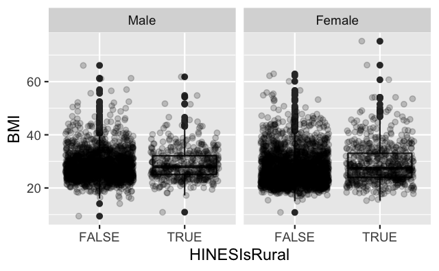

```r
ggplot(hines_cycle5 %>% filter(Stratum=="Low Minority Areas" & RacePreprocessed == "White") %>% filter(SelfGender %in% c("Male","Female")),aes(x=HINESIsRural,y=BMI) )+geom_boxplot()+geom_jitter(alpha=0.2)+facet_wrap(~SelfGender)
```

```r
hines_cycle5$height_m_recalculated <- as.numeric(as.character(hines_cycle5$Height_Feet))*0.3048+as.numeric(as.character(hines_cycle5$Height_Inches))*0.0254
```

```
NAs introduced by coercion
```

```r
hines_cycle5$Weight_kg<-as.numeric(as.character(hines_cycle5$Weight))*0.453592
```

```
NAs introduced by coercion
```

```r
hines_cycle5$BMI_recalculated <- hines_cycle5$Weight_kg/hines_cycle5$height_m_recalculated^2
```

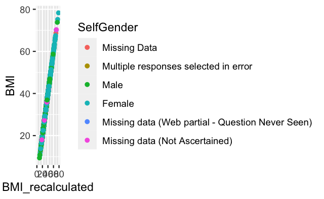

```r
ggplot(hines_cycle5,aes(BMI_recalculated,BMI,color=SelfGender))+geom_point()+coord_cartesian(xlim=c(0,80))
```

```r
NA
NA
```

```r
hines_cycle5 %>% filter(BMI_recalculated>(2*BMI)) %>% select(BMI,BMI_recalculated,Weight_kg,Weight,height_m_recalculated,Height_Feet,Height_Inches)
```

| BMI | BMI_recalculated | Weight_kg | Weight | height_m_recalculated | Height_Feet | Height_Inches |
| --- | --- | --- | --- | --- | --- | --- |

## Trying to further explain that rural-urban BMI gap

```r
data_to_measure <- hines_cycle5 %>%
  filter(SelfGender=="Female" & !is.na(HHInc_r))

model_w_income <- lm(BMI~Age_c+I(Age_c^2)+HINESIsRural+RacePreprocessed+filename+HHInc_r,data_to_measure)
model_no_income <- lm(BMI~Age_c+I(Age_c^2)+HINESIsRural+RacePreprocessed+filename,data_to_measure)

anova(model_no_income,model_w_income)
```

```
Analysis of Variance Table

Model 1: BMI ~ Age_c + I(Age_c^2) + HINESIsRural + RacePreprocessed +
    filename
Model 2: BMI ~ Age_c + I(Age_c^2) + HINESIsRural + RacePreprocessed +
    filename + HHInc_r
  Res.Df    RSS Df Sum of Sq     F    Pr(>F)
1   7596 361133
2   7595 354007  1    7126.5 152.9 < 2.2e-16 ***
---
Signif. codes:  0 ‘***’ 0.001 ‘**’ 0.01 ‘*’ 0.05 ‘.’ 0.1 ‘ ’ 1
```

```r
summary(model_w_income)
```

```
Call:
lm(formula = BMI ~ Age_c + I(Age_c^2) + HINESIsRural + RacePreprocessed +
    filename + HHInc_r, data = data_to_measure)

Residuals:
    Min      1Q  Median      3Q     Max
-17.935  -4.695  -1.260   3.434  47.705

Coefficients:
                                                   Estimate Std. Error t value Pr(>|t|)
(Intercept)                                      27.5225878  0.2010446 136.898  < 2e-16 ***
Age_c                                             0.1021127  0.0091884  11.113  < 2e-16 ***
I(Age_c^2)                                       -0.0034772  0.0002476 -14.046  < 2e-16 ***
HINESIsRuralTRUE                                  0.9187658  0.2302026   3.991 6.64e-05 ***
RacePreprocessedBlack                             2.7487209  0.2165289  12.694  < 2e-16 ***
RacePreprocessedMissing data (Not Ascertained)    0.5240658  0.4304493   1.217 0.223457
RacePreprocessedMultiple races selected           1.1833354  0.4096789   2.888 0.003882 **
RacePreprocessedChinese                          -5.7149593  0.7706839  -7.415 1.34e-13 ***
RacePreprocessedFilipino                         -2.1751981  0.7513182  -2.895 0.003800 **
RacePreprocessedAsian Indian                     -1.8435557  0.9630838  -1.914 0.055629 .
RacePreprocessedOther Asian                      -3.3237729  0.9722026  -3.419 0.000632 ***
RacePreprocessedAmerican Indian or Alaska Native  0.8414978  0.8611498   0.977 0.328512
RacePreprocessedPacific Islander                  1.7630560  1.0147492   1.737 0.082352 .
RacePreprocessedVietnamese                       -6.2461553  1.3988186  -4.465 8.11e-06 ***
RacePreprocessedKorean                           -4.5983032  1.6137002  -2.850 0.004390 **
RacePreprocessedJapanese                         -4.1841449  2.1622034  -1.935 0.053011 .
filenamehints5_cycle2_public.sav                  0.3426598  0.2393334   1.432 0.152263
filenamehints5_cycle3_public.sav                  0.4374514  0.2190177   1.997 0.045825 *
filenamehints5_cycle4_public.sav                  0.5237865  0.2354255   2.225 0.026121 *
HHInc_r                                          -0.6728059  0.0544117 -12.365  < 2e-16 ***
---
Signif. codes:  0 ‘***’ 0.001 ‘**’ 0.01 ‘*’ 0.05 ‘.’ 0.1 ‘ ’ 1

Residual standard error: 6.827 on 7595 degrees of freedom
  (249 observations deleted due to missingness)
Multiple R-squared:  0.09457,   Adjusted R-squared:  0.09231
F-statistic: 41.75 on 19 and 7595 DF,  p-value: < 2.2e-16
```

```r
#
```

let’s try a mediate approach

```r
library(mediation)
#model is:
data_to_measure <- hines_cycle5 %>%
  filter(SelfGender=="Female" & !is.na(HHInc_r) & !is.na(BMI))

#Rurality -> Income -> BMI
b <- lm(HHInc_r~Age_c+I(Age_c^2)+HINESIsRural+RacePreprocessed+filename,data_to_measure)
c <- lm(BMI~Age_c+I(Age_c^2)+HINESIsRural+RacePreprocessed+filename+HHInc_r,data_to_measure)

income_mediation <- mediate(b,c,sims=100,treat="HINESIsRural",mediator="HHInc_r")
summary(income_mediation)
```

```
Causal Mediation Analysis

Quasi-Bayesian Confidence Intervals

               Estimate 95% CI Lower 95% CI Upper p-value
ACME              0.274        0.199         0.35  <2e-16 ***
ADE               0.858        0.452         1.37  <2e-16 ***
Total Effect      1.133        0.715         1.65  <2e-16 ***
Prop. Mediated    0.249        0.161         0.38  <2e-16 ***
---
Signif. codes:  0 ‘***’ 0.001 ‘**’ 0.01 ‘*’ 0.05 ‘.’ 0.1 ‘ ’ 1

Sample Size Used: 7615


Simulations: 100
```

Income mediates 25% of the effect of rurality for BMI in women.

```r
summary(model_w_income)
```

```
Call:
lm(formula = BMI ~ Age_c + I(Age_c^2) + HINESIsRural + RacePreprocessed +
    filename + HHInc_r, data = data_to_measure)

Residuals:
    Min      1Q  Median      3Q     Max
-17.935  -4.695  -1.260   3.434  47.705

Coefficients:
                                                   Estimate Std. Error t value Pr(>|t|)
(Intercept)                                      27.5225878  0.2010446 136.898  < 2e-16 ***
Age_c                                             0.1021127  0.0091884  11.113  < 2e-16 ***
I(Age_c^2)                                       -0.0034772  0.0002476 -14.046  < 2e-16 ***
HINESIsRuralTRUE                                  0.9187658  0.2302026   3.991 6.64e-05 ***
RacePreprocessedBlack                             2.7487209  0.2165289  12.694  < 2e-16 ***
RacePreprocessedMissing data (Not Ascertained)    0.5240658  0.4304493   1.217 0.223457
RacePreprocessedMultiple races selected           1.1833354  0.4096789   2.888 0.003882 **
RacePreprocessedChinese                          -5.7149593  0.7706839  -7.415 1.34e-13 ***
RacePreprocessedFilipino                         -2.1751981  0.7513182  -2.895 0.003800 **
RacePreprocessedAsian Indian                     -1.8435557  0.9630838  -1.914 0.055629 .
RacePreprocessedOther Asian                      -3.3237729  0.9722026  -3.419 0.000632 ***
RacePreprocessedAmerican Indian or Alaska Native  0.8414978  0.8611498   0.977 0.328512
RacePreprocessedPacific Islander                  1.7630560  1.0147492   1.737 0.082352 .
RacePreprocessedVietnamese                       -6.2461553  1.3988186  -4.465 8.11e-06 ***
RacePreprocessedKorean                           -4.5983032  1.6137002  -2.850 0.004390 **
RacePreprocessedJapanese                         -4.1841449  2.1622034  -1.935 0.053011 .
filenamehints5_cycle2_public.sav                  0.3426598  0.2393334   1.432 0.152263
filenamehints5_cycle3_public.sav                  0.4374514  0.2190177   1.997 0.045825 *
filenamehints5_cycle4_public.sav                  0.5237865  0.2354255   2.225 0.026121 *
HHInc_r                                          -0.6728059  0.0544117 -12.365  < 2e-16 ***
---
Signif. codes:  0 ‘***’ 0.001 ‘**’ 0.01 ‘*’ 0.05 ‘.’ 0.1 ‘ ’ 1

Residual standard error: 6.827 on 7595 degrees of freedom
  (249 observations deleted due to missingness)
Multiple R-squared:  0.09457,   Adjusted R-squared:  0.09231
F-statistic: 41.75 on 19 and 7595 DF,  p-value: < 2.2e-16
```

What else?

```r
lm(BMI~Age_c+I(Age_c^2)+HINESIsRural+RacePreprocessed+filename+HHInc_r,data_to_measure)
```

Exercise?

```r
summary(lm(BMI~Age_c+I(Age_c^2)+HINESIsRural+RacePreprocessed+filename+HHInc_r+WeeklyMinutesModerateExercise,data_to_measure))
```

```
Call:
lm(formula = BMI ~ Age_c + I(Age_c^2) + HINESIsRural + RacePreprocessed +
    filename + HHInc_r + WeeklyMinutesModerateExercise, data = data_to_measure)

Residuals:
    Min      1Q  Median      3Q     Max
-19.849  -4.361  -0.911   3.250  46.010

Coefficients:
                                                  Estimate Std. Error t value Pr(>|t|)
(Intercept)                                      27.161507   0.609967  44.529  < 2e-16 ***
Age_c                                             0.100606   0.009022  11.151  < 2e-16 ***
I(Age_c^2)                                       -0.003682   0.000243 -15.154  < 2e-16 ***
HINESIsRuralTRUE                                  0.661379   0.225925   2.927 0.003428 **
RacePreprocessedBlack                             2.613010   0.213056  12.264  < 2e-16 ***
RacePreprocessedMissing data (Not Ascertained)    0.747193   0.425853   1.755 0.079372 .
RacePreprocessedMultiple races selected           1.222014   0.402932   3.033 0.002431 **
RacePreprocessedChinese                          -5.885360   0.751698  -7.829 5.58e-15 ***
RacePreprocessedFilipino                         -3.008033   0.733654  -4.100 4.17e-05 ***
RacePreprocessedAsian Indian                     -2.066218   0.938352  -2.202 0.027698 *
RacePreprocessedOther Asian                      -3.576952   0.965049  -3.706 0.000212 ***
RacePreprocessedAmerican Indian or Alaska Native  0.820565   0.841485   0.975 0.329523
RacePreprocessedPacific Islander                  1.648614   1.006194   1.638 0.101367
RacePreprocessedVietnamese                       -6.610855   1.363463  -4.849 1.27e-06 ***
RacePreprocessedKorean                           -4.453391   1.570760  -2.835 0.004592 **
RacePreprocessedJapanese                         -4.318768   2.107309  -2.049 0.040456 *
filenamehints5_cycle2_public.sav                  0.156493   0.236022   0.663 0.507322
filenamehints5_cycle3_public.sav                  0.407184   0.215664   1.888 0.059059 .
filenamehints5_cycle4_public.sav                  0.500739   0.232155   2.157 0.031044 *
HHInc_r                                          -0.500004   0.054367  -9.197  < 2e-16 ***
WeeklyMinutesModerateExercise0                    2.853562   0.585665   4.872 1.13e-06 ***
WeeklyMinutesModerateExercise1                    0.985492   3.883355   0.254 0.799678
WeeklyMinutesModerateExercise2                   -0.744337   3.381712  -0.220 0.825794
WeeklyMinutesModerateExercise3                    1.904067   2.576865   0.739 0.459986
WeeklyMinutesModerateExercise4                   19.138379   6.661901   2.873 0.004080 **
WeeklyMinutesModerateExercise5                    2.317454   2.418059   0.958 0.337895
WeeklyMinutesModerateExercise6                    0.225608   3.023441   0.075 0.940519
WeeklyMinutesModerateExercise7                    3.699413   4.731426   0.782 0.434309
WeeklyMinutesModerateExercise8                    1.149847   4.732744   0.243 0.808046
WeeklyMinutesModerateExercise10                   2.810816   1.357821   2.070 0.038478 *
```

[output cut: 120 more lines]

```
WeeklyMinutesModerateExercise177                 -7.394934   6.735295  -1.098 0.272267
WeeklyMinutesModerateExercise232                 -2.389243   6.660721  -0.359 0.719825
WeeklyMinutesModerateExercise325                 -2.269484   6.661687  -0.341 0.733356
WeeklyMinutesModerateExercise329                  5.082427   6.663161   0.763 0.445628
WeeklyMinutesModerateExercise483                 -4.332094   6.674654  -0.649 0.516335
WeeklyMinutesModerateExercise625                  0.191049   6.664792   0.029 0.977132
WeeklyMinutesModerateExercise870                 -5.376394   6.661436  -0.807 0.419639
WeeklyMinutesModerateExercise2500                -1.249365   6.668640  -0.187 0.851392
---
Signif. codes:  0 ‘***’ 0.001 ‘**’ 0.01 ‘*’ 0.05 ‘.’ 0.1 ‘ ’ 1

Residual standard error: 6.634 on 7457 degrees of freedom
  (72 observations deleted due to missingness)
Multiple R-squared:  0.1606,    Adjusted R-squared:  0.1429
F-statistic: 9.085 on 157 and 7457 DF,  p-value: < 2.2e-16
```

```r
library(mediation)
#model is:
data_to_measure <- hines_cycle5 %>%
  filter(SelfGender=="Female" & !is.na(HHInc_r) & !is.na(BMI) & !is.na(WeeklyMinutesModerateExercise_i))
data_to_measure$WeeklyMinutesModerateExercise_z<-(
  (data_to_measure$WeeklyMinutesModerateExercise_i-mean(data_to_measure$WeeklyMinutesModerateExercise_i,na.rm=TRUE))/
    sd(data_to_measure$WeeklyMinutesModerateExercise_i,na.rm=TRUE))

#Rurality -> Income -> BMI
b <- lm(WeeklyMinutesModerateExercise_z~Age_c+I(Age_c^2)+HINESIsRural+RacePreprocessed+filename+HHInc_r,data_to_measure)
c <- lm(BMI~Age_c+I(Age_c^2)+HINESIsRural+RacePreprocessed+filename+HHInc_r+WeeklyMinutesModerateExercise_z,data_to_measure)

exercise_mediation <- mediate(b,c,sims=100,treat="HINESIsRural",mediator="WeeklyMinutesModerateExercise_z")
summary(exercise_mediation)
```

```
Causal Mediation Analysis

Quasi-Bayesian Confidence Intervals

               Estimate 95% CI Lower 95% CI Upper p-value
ACME             0.0204      -0.0401         0.08    0.38
ADE              0.9114       0.5225         1.38  <2e-16 ***
Total Effect     0.9317       0.5587         1.37  <2e-16 ***
Prop. Mediated   0.0156      -0.0435         0.10    0.38
---
Signif. codes:  0 ‘***’ 0.001 ‘**’ 0.01 ‘*’ 0.05 ‘.’ 0.1 ‘ ’ 1

Sample Size Used: 7478


Simulations: 100
```

```r
summary(c)
```

```
Call:
lm(formula = BMI ~ Age_c + I(Age_c^2) + HINESIsRural + RacePreprocessed +
    filename + HHInc_r + WeeklyMinutesModerateExercise_z, data = data_to_measure)

Residuals:
    Min      1Q  Median      3Q     Max
-18.371  -4.643  -1.231   3.455  47.288

Coefficients:
                                                   Estimate Std. Error t value Pr(>|t|)
(Intercept)                                      27.7209796  0.2015211 137.559  < 2e-16 ***
Age_c                                             0.1018872  0.0092068  11.067  < 2e-16 ***
I(Age_c^2)                                       -0.0035362  0.0002494 -14.176  < 2e-16 ***
HINESIsRuralTRUE                                  0.9240315  0.2309845   4.000 6.38e-05 ***
RacePreprocessedBlack                             2.7835275  0.2178213  12.779  < 2e-16 ***
RacePreprocessedMissing data (Not Ascertained)    0.6232299  0.4312535   1.445 0.148455
RacePreprocessedMultiple races selected           1.1102081  0.4114195   2.698 0.006981 **
RacePreprocessedChinese                          -5.7789918  0.7709860  -7.496 7.36e-14 ***
RacePreprocessedFilipino                         -2.4414918  0.7472094  -3.267 0.001090 **
RacePreprocessedAsian Indian                     -1.9717589  0.9574185  -2.059 0.039485 *
RacePreprocessedOther Asian                      -3.4616891  0.9665090  -3.582 0.000344 ***
RacePreprocessedAmerican Indian or Alaska Native  0.6285742  0.8770642   0.717 0.473594
RacePreprocessedPacific Islander                  1.6798451  1.0088396   1.665 0.095930 .
RacePreprocessedVietnamese                       -6.4193880  1.3905277  -4.617 3.97e-06 ***
RacePreprocessedKorean                           -4.6441908  1.6040508  -2.895 0.003799 **
RacePreprocessedJapanese                         -4.3328452  2.1492502  -2.016 0.043838 *
filenamehints5_cycle2_public.sav                  0.1282932  0.2403496   0.534 0.593511
filenamehints5_cycle3_public.sav                  0.2698516  0.2195251   1.229 0.219016
filenamehints5_cycle4_public.sav                  0.3790600  0.2361535   1.605 0.108505
HHInc_r                                          -0.6666598  0.0546742 -12.193  < 2e-16 ***
WeeklyMinutesModerateExercise_z                  -0.8996426  0.0787286 -11.427  < 2e-16 ***
---
Signif. codes:  0 ‘***’ 0.001 ‘**’ 0.01 ‘*’ 0.05 ‘.’ 0.1 ‘ ’ 1

Residual standard error: 6.786 on 7457 degrees of freedom
  (67 observations deleted due to missingness)
Multiple R-squared:  0.1104,    Adjusted R-squared:  0.108
F-statistic: 46.28 on 20 and 7457 DF,  p-value: < 2.2e-16
```

Exercise, while significant as an explanatory factor (standardized beta=-0.9, p<0.001) doesn’t significantly mediate our rural-urban gap.

What about eating? There are two eating scales in this survey–cups of vegetables eaten and cups of fruit eaten. But they’re only run for a few cycles. We can still measrue those though I think?

```r
data_to_measure <- hines_cycle5 %>%
  filter(SelfGender=="Female" & !is.na(HHInc_r) & !is.na(BMI) & !is.na(Fruit_z) & !is.na(Vegetables_z))


data_to_measure %>% group_by(HINESIsRural) %>% summarize(count=n())
```

| HINESIsRural | count |
| --- | --- |
| FALSE | 2987 |
| TRUE | 445 |

```r
library(mediation)

#Rurality -> Income -> BMI
mb <- lm(Fruit_z~Age_c+I(Age_c^2)+HINESIsRural+RacePreprocessed+filename+HHInc_r,data_to_measure)
mc <- lm(BMI~Age_c+I(Age_c^2)+HINESIsRural+RacePreprocessed+filename+HHInc_r+Fruit_z,data_to_measure)

fruit_mediation <- mediate(mb,mc,sims=100,treat="HINESIsRural",mediator="Fruit_z")
summary(fruit_mediation)
```

```
Causal Mediation Analysis

Quasi-Bayesian Confidence Intervals

               Estimate 95% CI Lower 95% CI Upper p-value
ACME             0.0395      -0.0227         0.11    0.18
ADE              1.2315       0.5610         1.89  <2e-16 ***
Total Effect     1.2710       0.6122         1.93  <2e-16 ***
Prop. Mediated   0.0312      -0.0252         0.09    0.18
---
Signif. codes:  0 ‘***’ 0.001 ‘**’ 0.01 ‘*’ 0.05 ‘.’ 0.1 ‘ ’ 1

Sample Size Used: 3404


Simulations: 100
```

```r
summary(mc)
```

```
Call:
lm(formula = BMI ~ Age_c + I(Age_c^2) + HINESIsRural + RacePreprocessed +
    filename + HHInc_r + Fruit_z, data = data_to_measure)

Residuals:
    Min      1Q  Median      3Q     Max
-17.330  -4.572  -1.320   3.510  43.863

Coefficients:
                                                   Estimate Std. Error t value Pr(>|t|)
(Intercept)                                      27.4523174  0.2705082 101.484  < 2e-16 ***
Age_c                                             0.0976528  0.0138800   7.036 2.39e-12 ***
I(Age_c^2)                                       -0.0033158  0.0003828  -8.662  < 2e-16 ***
HINESIsRuralTRUE                                  1.2487259  0.3477736   3.591 0.000335 ***
RacePreprocessedBlack                             3.1885307  0.3197111   9.973  < 2e-16 ***
RacePreprocessedMissing data (Not Ascertained)   -0.0084667  0.6627869  -0.013 0.989809
RacePreprocessedMultiple races selected           2.1646007  0.6174087   3.506 0.000461 ***
RacePreprocessedChinese                          -4.7448577  1.1040930  -4.298 1.78e-05 ***
RacePreprocessedFilipino                         -1.6667841  1.1021340  -1.512 0.130545
RacePreprocessedAsian Indian                     -1.6585602  1.5178828  -1.093 0.274612
RacePreprocessedOther Asian                      -4.3309305  1.6420271  -2.638 0.008389 **
RacePreprocessedAmerican Indian or Alaska Native  0.1190861  1.3859325   0.086 0.931531
RacePreprocessedPacific Islander                  1.5137833  1.5564791   0.973 0.330837
RacePreprocessedVietnamese                       -5.6343222  1.7485382  -3.222 0.001284 **
RacePreprocessedKorean                           -4.1527381  1.9501369  -2.129 0.033288 *
RacePreprocessedJapanese                         -4.2194160  2.7556511  -1.531 0.125817
filenamehints5_cycle3_public.sav                  0.3387432  0.2635844   1.285 0.198831
HHInc_r                                          -0.6726492  0.0810344  -8.301  < 2e-16 ***
Fruit_z                                          -0.5634960  0.1203862  -4.681 2.97e-06 ***
---
Signif. codes:  0 ‘***’ 0.001 ‘**’ 0.01 ‘*’ 0.05 ‘.’ 0.1 ‘ ’ 1

Residual standard error: 6.736 on 3385 degrees of freedom
  (28 observations deleted due to missingness)
Multiple R-squared:  0.1129,    Adjusted R-squared:  0.1082
F-statistic: 23.94 on 18 and 3385 DF,  p-value: < 2.2e-16
```

Again, like exercise, eating fruit is significantly related to BMI (B=-0.56,p<0.001) but doesn’t significantly mediate the rural-urban effect.

```r
library(mediation)

#Rurality -> Income -> BMI
mb <- lm(Vegetables_z~Age_c+I(Age_c^2)+HINESIsRural+RacePreprocessed+filename+HHInc_r,data_to_measure)
mc <- lm(BMI~Age_c+I(Age_c^2)+HINESIsRural+RacePreprocessed+filename+HHInc_r+Vegetables_z,data_to_measure)

vegetables_mediation <- mediate(mb,mc,sims=100,treat="HINESIsRural",mediator="Vegetables_z")
```

```r
data_to_measure <- hines_cycle5 %>%
  filter(SelfGender=="Female" & !is.na(HHInc_r) & !is.na(BMI) & !is.na(CENSDIV))


data_to_measure %>% group_by(HINESIsRural) %>% summarize(count=n())
```

| HINESIsRural | count |
| --- | --- |
| FALSE | 6630 |
| TRUE | 1057 |

```r
library(mediation)

#Rurality -> Income -> BMI
mb <- lm(CENSDIV~Age_c+I(Age_c^2)+HINESIsRural+RacePreprocessed+filename+HHInc_r,data_to_measure)
```

```
using type = "numeric" with a factor response will be ignored‘-’ not meaningful for factors
```

```r
mc <- lm(BMI~Age_c+I(Age_c^2)+HINESIsRural+RacePreprocessed+filename+HHInc_r+CENSDIV,data_to_measure)

CENSDIV_mediation <- mediate(mb,mc,sims=100,treat="HINESIsRural",mediator="CENSDIV")
```

```
‘^’ not meaningful for factorsError in eigen(sigma, symmetric = TRUE) :
  infinite or missing values in 'x'
```

## General Food consumption/BMI relationship

```r
data_to_measure <- hines_cycle5

data_to_measure$Fruit_and_vege_z <-data_to_measure$Vegetables_z+data_to_measure$Fruit_z
summary(lm(BMI~Age_c+SelfGender+RacePreprocessed+Fruit_and_vege_z,data_to_measure))
```

```
Call:
lm(formula = BMI ~ Age_c + SelfGender + RacePreprocessed + Fruit_and_vege_z,
    data = data_to_measure)

Residuals:
    Min      1Q  Median      3Q     Max
-19.206  -4.318  -1.113   3.126  47.437

Coefficients: (1 not defined because of singularities)
                                                                  Estimate Std. Error t value Pr(>|t|)
(Intercept)                                                      27.573673   0.357140  77.207  < 2e-16 ***
Age_c                                                             0.006039   0.004685   1.289 0.197373
SelfGenderMale                                                    0.454197   0.350323   1.297 0.194844
SelfGenderFemale                                                  0.443353   0.346801   1.278 0.201150
SelfGenderMissing data (Web partial - Question Never Seen)        0.266833   1.270887   0.210 0.833707
RacePreprocessedBlack                                             2.922794   0.219255  13.331  < 2e-16 ***
RacePreprocessedMissing data (Not Ascertained)                    0.639379   0.348449   1.835 0.066560 .
RacePreprocessedMultiple races selected                           1.699845   0.415088   4.095 4.27e-05 ***
RacePreprocessedChinese                                          -4.417181   0.706623  -6.251 4.32e-10 ***
RacePreprocessedFilipino                                         -1.862025   0.810295  -2.298 0.021594 *
RacePreprocessedAsian Indian                                     -2.992959   0.825290  -3.627 0.000289 ***
RacePreprocessedOther Asian                                      -3.119161   1.034055  -3.016 0.002567 **
RacePreprocessedAmerican Indian or Alaska Native                  0.514453   1.032744   0.498 0.618400
RacePreprocessedPacific Islander                                  1.269067   1.160816   1.093 0.274321
RacePreprocessedVietnamese                                       -5.756035   1.124394  -5.119 3.15e-07 ***
RacePreprocessedMissing data (Web partial - Question Never Seen)        NA         NA      NA       NA
RacePreprocessedKorean                                           -3.958179   1.223152  -3.236 0.001218 **
RacePreprocessedJapanese                                         -4.033884   1.386595  -2.909 0.003635 **
Fruit_and_vege_z                                                 -0.402192   0.044085  -9.123  < 2e-16 ***
---
Signif. codes:  0 ‘***’ 0.001 ‘**’ 0.01 ‘*’ 0.05 ‘.’ 0.1 ‘ ’ 1

Residual standard error: 6.337 on 6829 degrees of freedom
  (9245 observations deleted due to missingness)
Multiple R-squared:  0.05793,   Adjusted R-squared:  0.05558
F-statistic:  24.7 on 17 and 6829 DF,  p-value: < 2.2e-16
```

```r
summary(lm(BMI~Age_c+I(Age_c^2)+SelfGender+RacePreprocessed+filename+Fruit_and_vege_z,data_to_measure))
```

```
Call:
lm(formula = BMI ~ Age_c + I(Age_c^2) + SelfGender + RacePreprocessed +
    filename + Fruit_and_vege_z, data = data_to_measure)

Residuals:
    Min      1Q  Median      3Q     Max
-19.078  -4.197  -1.090   3.080  47.238

Coefficients: (1 not defined because of singularities)
                                                                   Estimate Std. Error t value Pr(>|t|)
(Intercept)                                                      27.8549171  0.3786197  73.570  < 2e-16 ***
Age_c                                                             0.1006343  0.0093590  10.753  < 2e-16 ***
I(Age_c^2)                                                       -0.0028553  0.0002456 -11.625  < 2e-16 ***
SelfGenderMale                                                    0.2065383  0.3476726   0.594 0.552492
SelfGenderFemale                                                  0.2748732  0.3438440   0.799 0.424079
SelfGenderMissing data (Web partial - Question Never Seen)        0.4310349  1.2592173   0.342 0.732133
RacePreprocessedBlack                                             2.7467243  0.2176623  12.619  < 2e-16 ***
RacePreprocessedMissing data (Not Ascertained)                    0.6747692  0.3452032   1.955 0.050659 .
RacePreprocessedMultiple races selected                           1.6550889  0.4111013   4.026 5.74e-05 ***
RacePreprocessedChinese                                          -4.1049947  0.7003824  -5.861 4.81e-09 ***
RacePreprocessedFilipino                                         -1.9830523  0.8025344  -2.471 0.013498 *
RacePreprocessedAsian Indian                                     -2.8002292  0.8175721  -3.425 0.000618 ***
RacePreprocessedOther Asian                                      -3.0897269  1.0240535  -3.017 0.002561 **
RacePreprocessedAmerican Indian or Alaska Native                  0.6033646  1.0228212   0.590 0.555276
RacePreprocessedPacific Islander                                  1.0059767  1.1500063   0.875 0.381737
RacePreprocessedVietnamese                                       -5.8534262  1.1136640  -5.256 1.52e-07 ***
RacePreprocessedMissing data (Web partial - Question Never Seen)         NA         NA      NA       NA
RacePreprocessedKorean                                           -4.1055733  1.2114119  -3.389 0.000705 ***
RacePreprocessedJapanese                                         -4.0830281  1.3731879  -2.973 0.002956 **
filenamehints5_cycle3_public.sav                                 -0.0767293  0.1740262  -0.441 0.659294
Fruit_and_vege_z                                                 -0.4110969  0.0438923  -9.366  < 2e-16 ***
---
Signif. codes:  0 ‘***’ 0.001 ‘**’ 0.01 ‘*’ 0.05 ‘.’ 0.1 ‘ ’ 1

Residual standard error: 6.276 on 6827 degrees of freedom
  (9245 observations deleted due to missingness)
Multiple R-squared:  0.07634,   Adjusted R-squared:  0.07377
F-statistic:  29.7 on 19 and 6827 DF,  p-value: < 2.2e-16
```

```r
summary(lm(BMI~Age_c+I(Age_c^2)+SelfGender+RacePreprocessed+filename+Fruit_and_vege_z+I(Fruit_and_vege_z^2),data_to_measure))
```

```
Call:
lm(formula = BMI ~ Age_c + I(Age_c^2) + SelfGender + RacePreprocessed +
    filename + Fruit_and_vege_z + I(Fruit_and_vege_z^2), data = data_to_measure)

Residuals:
    Min      1Q  Median      3Q     Max
-19.081  -4.203  -1.095   3.083  47.223

Coefficients: (1 not defined because of singularities)
                                                                   Estimate Std. Error t value Pr(>|t|)
(Intercept)                                                      27.8705379  0.3840829  72.564  < 2e-16 ***
Age_c                                                             0.1006400  0.0093597  10.752  < 2e-16 ***
I(Age_c^2)                                                       -0.0028560  0.0002457 -11.626  < 2e-16 ***
SelfGenderMale                                                    0.2079784  0.3477472   0.598 0.549811
SelfGenderFemale                                                  0.2751188  0.3438692   0.800 0.423699
SelfGenderMissing data (Web partial - Question Never Seen)        0.4335593  1.2593471   0.344 0.730652
RacePreprocessedBlack                                             2.7491143  0.2179002  12.616  < 2e-16 ***
RacePreprocessedMissing data (Not Ascertained)                    0.6750408  0.3452288   1.955 0.050583 .
RacePreprocessedMultiple races selected                           1.6572787  0.4112288   4.030 5.64e-05 ***
RacePreprocessedChinese                                          -4.1029943  0.7004792  -5.857 4.92e-09 ***
RacePreprocessedFilipino                                         -1.9831358  0.8025898  -2.471 0.013501 *
RacePreprocessedAsian Indian                                     -2.8016624  0.8176498  -3.426 0.000615 ***
RacePreprocessedOther Asian                                      -3.0884775  1.0241371  -3.016 0.002573 **
RacePreprocessedAmerican Indian or Alaska Native                  0.6071725  1.0230122   0.594 0.552857
RacePreprocessedPacific Islander                                  1.0030580  1.1501485   0.872 0.383178
RacePreprocessedVietnamese                                       -5.8487896  1.1139048  -5.251 1.56e-07 ***
RacePreprocessedMissing data (Web partial - Question Never Seen)         NA         NA      NA       NA
RacePreprocessedKorean                                           -4.1060933  1.2114973  -3.389 0.000705 ***
RacePreprocessedJapanese                                         -4.0724091  1.3739801  -2.964 0.003048 **
filenamehints5_cycle3_public.sav                                 -0.0803738  0.1746856  -0.460 0.645455
Fruit_and_vege_z                                                 -0.4104804  0.0439688  -9.336  < 2e-16 ***
I(Fruit_and_vege_z^2)                                            -0.0045425  0.0187265  -0.243 0.808347
---
Signif. codes:  0 ‘***’ 0.001 ‘**’ 0.01 ‘*’ 0.05 ‘.’ 0.1 ‘ ’ 1

Residual standard error: 6.276 on 6826 degrees of freedom
  (9245 observations deleted due to missingness)
Multiple R-squared:  0.07635,   Adjusted R-squared:  0.07364
F-statistic: 28.21 on 20 and 6826 DF,  p-value: < 2.2e-16
```